# Foto_Analyses

Robin von Allmen

18 3 2021

## Preparing Data

```r
#setwd("~/GitHub/Ichneumonidae/R-Scripts")
landmark = readland.tps("FOTO_ICHNEU.TPS",specID = "ID", readcurves = T, warnmsg = TRUE)
landmark2 = readland.tps("FOTO_ICHNEU.tps",specID = "ID", readcurves = F, warnmsg = TRUE)
```

```
##      define classifiers (subfam or tribes)
```

```r
species = as.factor( substr( dimnames(landmark)[[3]], 1, 6))
subfam = as.factor( substr( dimnames(landmark)[[3]], 8, 13))
areolet = as.factor( substr( dimnames(landmark)[[3]], 15, 15))
tribe = as.factor( substr( dimnames(landmark)[[3]], 17, 19))
foto = as.factor( substr( dimnames(landmark)[[3]], 24,24))

##      define Semilandmarks, first LM is the start, last one the end (those are both
##      fixed landmarks, in between are the semilandmarks):
sliders = define.sliders(c(15,22:29,16))

##      procrustes fit - "superimposition" - rotates and scales the landmarks to their closest distance,
##      minimizing the shape and size difference:
proD<-gpagen(landmark, surfaces = NULL, curves = sliders,
             PrinAxes = FALSE, max.iter = NULL, ProcD = F, Proj = TRUE,
             print.progress = TRUE)

proD2<-gpagen(landmark2, surfaces = NULL,
             PrinAxes = FALSE, max.iter = NULL, ProcD = F, Proj = TRUE,
             print.progress = TRUE)
```

## PCA Analysis

Looking at the model on the left we see that there is little variation between the specimen whose source were either fotos or illustrations. However there are some pretty strong outliers in the second plot without the curve, mainly due to PC1. Which looking at the procrustes fit overall belongs to LM #1 which makes sense, since it was oftenly difficult to identify this point on the graph. For further analysis I therefore recommend to ignore that.

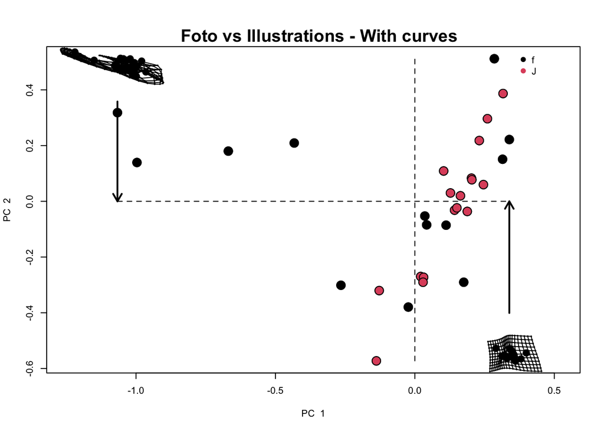

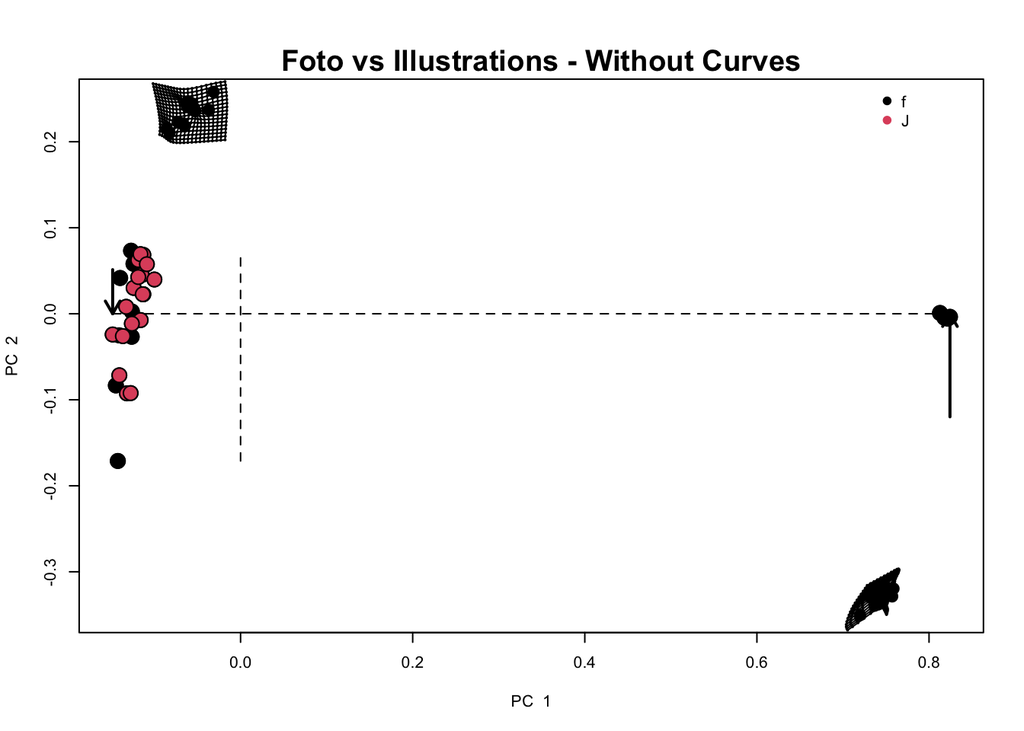

In this plot we took the data with the curves and also did plot the Data from PC2 vs PC3 as we would expect to obtain more consistent data.

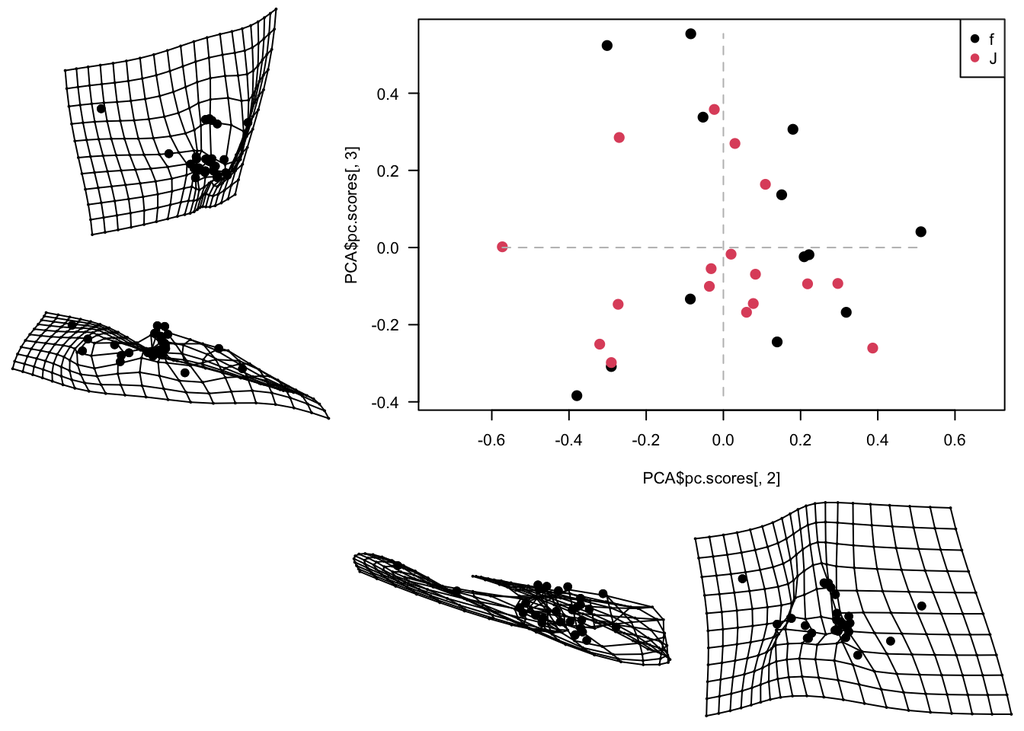

## 3D-Plot

with the PCA scores u are also able to generate 3d plots which compare several Principal Components at once: Here we also se, that the PC1 has an extreme impact on the variation.

```r
colors = c("red","cyan")[subfam]
plot3d(PCA1$pc.scores[,1:3], col = colors, size = 9)
text3d(PCA1$pc.scores[,1:3],texts=species,pos=4,cex= 0.6)
legend3d("topright", legend = c("Gelinae","Ichneumoninae"), col = c("red","cyan") , pch= 16)
```

[interactive chart not shown]

#Complete DataSet with mixed Fotos and Illustrations

In order to tell wether our new Data-Collection is efficient to predict specimen orders that are made from photos, we determined how big the influence of these are on the overall analysis.(these two plots contain no curve data and plot PC2 vs PC3)

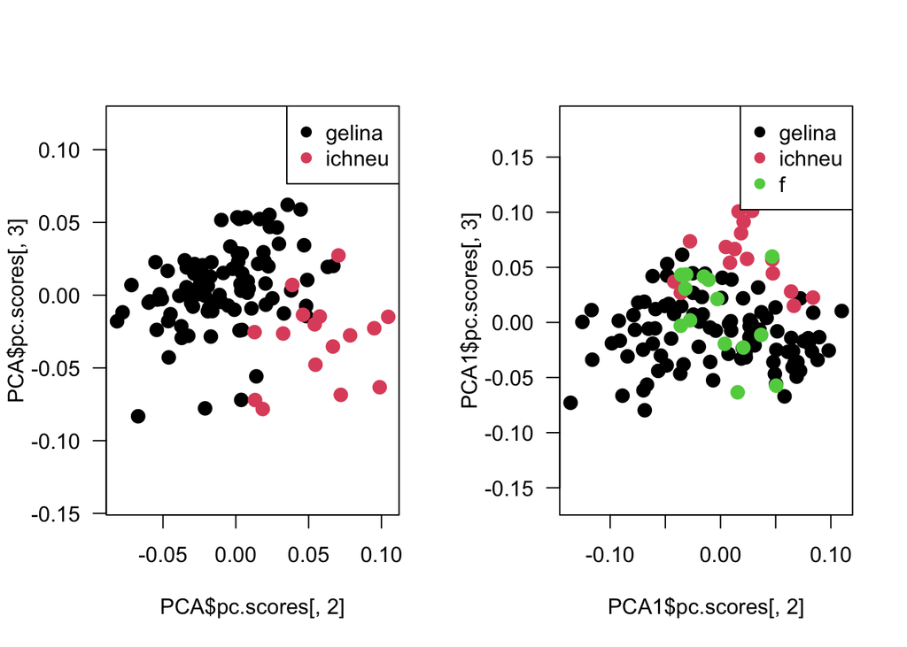

```r
par(mfrow=c(1,2)) # sets the margins

plot(PCA$pc.scores[,2],PCA$pc.scores[,3], col=subfam1, asp=T, las=1,pch=16, cex=1.5)
legend("topright", legend= levels(subfam1), col=palette(), pch=rep(19,14) )
plot(PCA1$pc.scores[,2],PCA1$pc.scores[,3], col=subfam2, asp=T, las=1,pch=16, cex=1.5)
legend("topright", legend= levels(subfam2), col=palette(), pch=rep(19,14) )
```

However comparing the graphs from the Data Set with and without Fotos there is clearly a tendance of the specimen from the fotos to mingle in between the other subfamily which clearly is unwantend. But still a big amoung of green dots which actually belong to Ichneumoninae still are close to the pink colour. So the important thing now is to identify the landmarks which have the most impact on this variation and to sort out fotos from specimen where these points are not clearly indicated.